# Chapter 2: Data and Sampling Distributions

```r
# Load libraries
library(tidyverse)
library(RColorBrewer)
library(ggtext)
library(boot)
library(kableExtra)
library(patchwork)

# Set ggplot2 theme
my_theme <- theme(
  panel.background = element_rect(fill = "white",
                                  color = "black"),
  panel.grid = element_blank(),
  plot.title = element_markdown(),
  plot.subtitle = element_markdown()
)
```

## Introduction

In general, we’re interested in understanding fundamental processes about a population, which cannot be measured directly. Thus, the population distribution is typically unknown, so we take representative samples from that broader population and rely on various assumptions to make inference about the population from the sample.

## Random Sampling and Sample Bias

Ideally, all samples are drawn from a population at random, meaning that any member of the population has an equal probability of being sampled. Samples may be stratified random if groups are first subdivided, and then sampled randomly from within their respective groups. For example, if you were enrolling patients in a clinical trial to measure the efficacy of a new therapeutic agent, you could first divide participants into “experimental” and “control” groups. Within these groups, you could then randomly select volunteers that could be drawn to be used in the study to minimize bias. Bias is systematic error that could arise from a number of different issues, including confounding factors, known issues with the estimator given the sampling design, etc. In a sampling scheme, sampling bias refers to the collection of a non-representative sample from a population. The key concept of sampling bias is the methodology used to collect the sample, in that it will likely generate biased samples in the future with the same approach. For example, product reviews are often biased because the probability of someone writing one of the reviews is not random: it is likely that the authors are on the extreme ends of the distribution regarding their satisfaction Further, not everyone would typically take the time to write a review in the first place. Thus, if your purchasing decisions were based exclusively on reviews from Amazon or another retailer, your interpretation of the products would likely be biased. Bias can also creep into an analysis intentionally or unintentionally in processes collectively known as selection bias. This could include trying to find hidden patterns in data that fit preconceived ideas, or modifying pre-planned experimental designs when interesting patterns emerge.

## Regression to the Mean

Although the concept of regression to the mean is somewhat confusing, it is an important concept that demonstrates selection bias in many different examples. The idea postulates that extreme observations tend to be followed by less extreme, or central, observations. The authors used the example of sports performance and the “rookie of the year” effect, where there are some players that tend to do extremely well, far better than others, during their first year. This is largely a combination of skill and luck, the latter of which wears off after the first year, so the performance of those players tends to drop the second year towards less extreme values.

## Sampling Distribution of a Statistic

A few terms to describe sampling distributions and related metrics are described below:

- Sampling distributions refer to the distribution of a sample statistic obtained over repeated sampling. For instance, the sample distribution of the sample mean is the distribution of the mean of a sample, obtained through repeated measurements to find the sample mean.
- Data distributions refer to the distribution of values in a dataset.
- The central limit theorem describes the observation that as sample sizes increase, the data distribution tends to become more normal, or bell-shaped.

```r
# Load the lc_loans data
loans_income <- read_csv("../data/loans_income.csv") %>%
  rename(annual_income = x)

# Sample 1000 observations without replacement (default)
data_distribution <- data.frame(income = sample(loans_income$annual_income, 1000),
           type = "data_distribution")

# Take a sample of means of 5 values
# The code works by sampling 1,000 values, 5 times to generate an array
# Then, from 1 to 1,000 values, rep 5 values 1,000 times and take the mean to generate 1,000 sample means of 5 values
sample_mean_05 <- data.frame(income = tapply(sample(loans_income$annual_income, 1000*5),
       rep(1:1000, rep(5, 1000)), FUN = mean),
       type = "sample_mean_05")

# Now do the same thing for a sample of means of 20 values
sample_mean_20 <- data.frame(income = tapply(sample(loans_income$annual_income, 1000*20),
       rep(1:1000, rep(20, 1000)), FUN = mean),
       type = "sample_mean_20")

# Put all observations in data frames
income_data_combined <- rbind(data_distribution,
                              sample_mean_05,
                              sample_mean_20)

# Plot
income_data_combined %>%
  mutate(income = as.numeric(income),
         type = case_when(
           type == "data_distribution" ~ "Data distribution",
           type == "sample_mean_05" ~ "Sample of 5 means",
           TRUE ~ "Sample of 20 means"
         )) %>%
  ggplot(aes(income)) +
  geom_histogram(bins = 40) +
  facet_grid(type ~ .,
             scales = "fixed") +
  my_theme +
  labs(x = "Income (USD)",
       y = "Count",
       title = "Distribution of loan income data, sample of 20 means, and sample of 5 means")
```

[output not shown]

## Standard Error

The standard error describes the variability around estimated sample statistics. It is calculated by dividing the standard deviation of the sample statistics by the square root of the sample size. It holds that as the sample size increases, the standard error, or the variability in sample statistics, decreases. This is intuitive: if you repeatedly collect samples to calculate the sample mean, the variability in your estimates will likely be greater if you only take 5 samples to calculate the sample means as opposed to 20 samples. In fact, we can calculate the standard error from the previous exercises. The standard error for 1,000 samples of 5 means is approximately 470; the standard error for 1,000 samples of 20 means is approximately 232. This demonstrates the concept of the central limit theorem, but it relies on repeatedly collecting samples, which may not be feasible in some situations. Instead, the bootstrap method is often utilized to calculate the standard error.

```r
# Calculate the standard error of the 1000 samples of 20 means
sd(sample_mean_20$income) / sqrt(1000)
```

```
[1] 232.7901
```

## The Bootstrap

One of the most powerful methods for calculating the sampling distribution of a test statistic is to use the bootstrap, which draws repeated samples from the data (with replacement, meaning the same observations may be drawn 0, 1, or many times). This method makes no assumptions about the underlying distribution of the data or the sample statistic (e.g., that the sampling distribution of the test statistic is normally distributed). For example, if we wanted to estimate the standard error of the sample mean by boostrapping, we would draw an observation from the original data, record the value, then replace the observation. Recall, that observation may be drawn 0, 1, or many more times. After a defined number of draws, we can calculate the sample mean, and repeat the entire process over again. Then, we can calculate the standard deviation and divide by the square root of the sample size to obtain an estimate of the standard error. In general, the higher the number of bootstraps, the more accurate the estimate of the standard error will be. We’ll use the `boot` package to draw repeated samples from the `loans_income` data and calculate the median value. [This page](https://www.mayin.org/ajayshah/KB/R/documents/boot.html) provides a good introduction to using the `boot()` function. Essentially, we’ll write a function that will take two arguments: the data to operate on, and a variable to hold indexes for subsetting the original data. The `boot()` function will draw a set of indexes to subset the original data and pass the function (e.g., `median()`), for each iteration (or repetition), store the resulting value, and then draw a new set of indexes.

```r
# Print the summary of the bootstrap object
boot_obj
```

```
ORDINARY NONPARAMETRIC BOOTSTRAP


Call:
boot(data = loans_income$annual_income, statistic = stat_function,
    R = 1000)


Bootstrap Statistics :
    original   bias    std. error
t1*    62000 -80.3165    222.9262
```

The resulting class `boot` object provides information on the parameters passed in the function call and the overall bootstrap statistics: the original value of the statistic (i.e., the median) calculated from the original data, without bootstrapping; the bias, which is the difference between the estimated value (i.e., the value estimated from bootstrap resampling) and the actual value; and the standard error, or the standard deviation of the test statistic (i.e., the median) divided by the square root of the sample size. In this case, the bias estimate is negative, meaning the actual value is greater than the expected value; in other words, the bootstrap resampling method underestimated the median annual income.

```r
# Get the summary information
summary(boot_obj)
```

```
          Length Class  Mode
t0            1  -none- numeric
t          1000  -none- numeric
R             1  -none- numeric
data      50000  -none- numeric
seed        626  -none- numeric
statistic     1  -none- function
sim           1  -none- character
call          4  -none- call
stype         1  -none- character
strata    50000  -none- numeric
weights   50000  -none- numeric
```

There are additional data in the `boot` object. Some of them are defined below:

- `t0`: this is the actual value calculated from the original data.
- `t`: matrix object with the value of the statistic for each of the bootstrap replicates.
- `R`: the value of `R` passed to the function `boot()`, or the number of bootstrap replicates.
- `data`: the original data passed to the `boot()` function.
- `seed`: the value of `.Random.seed` passed to `boot()` (if you want to replicate the results, set the seed).

We can see how well the bootstrapped estimate compared to the actual estimate by plotting the bootstrap estimates and labeling the actual median in a density plot.

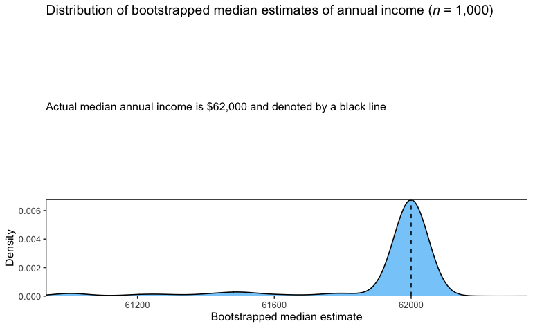

From this plot, we can see that a large proportion of the bootstrapped median estimates of annual income are close to the actual estimate. However, because the bootstrap sampling procedure is random, the estimates may be slightly different, hence why some of the estimates are relatively low compared to the actual estimate (e.g., $61,200), which leads to the negative bias. Let’s try this again with 10,000 boostrap replicates and see how the sampling distribution of the median changes with more replicates.

```r
# Print data output
boot_obj_v2
```

```
ORDINARY NONPARAMETRIC BOOTSTRAP


Call:
boot(data = loans_income$annual_income, statistic = stat_function,
    R = 10000)


Bootstrap Statistics :
    original    bias    std. error
t1*    62000 -75.27755    217.7925
```

We can see that additional bootstrap resamplings did a little bit better, but still tends to underestimate the median annual income. This highlights an important consideration when using the bootstrap- it doesn’t create new data, so it cannot resolve issues with data quality or gaps that are present in the original data. It is an approach to evaluate how repeated sampling would impact the sampling distribution if repeated samples were drawn from a population similar to the original data.

## Confidence Intervals

Confidence intervals help to quantify uncertainty around estimates, and can be practically thought of as the percentage of sample estimates that should contain additional sample estimates, assuming that similar sampling procedures are used in the future. For example, if we wanted to estimate the mean male human height in an office, we could sample 100 males and estimate the mean of the population using that sample. We could then calculate the confidence interval around that point estimate of the sample mean to estimate the percentage of resamplings that would also contain that same sample mean if we used a similar sort of sampling procedure. In the context of bootstrap resampling, we could say that a 95% confidence interval is the central 95% of the bootstrap sampling estimates (essentially trimming the most extreme values from either end of the distribution).

We can recreate the figure from the textbook to demonstrate how to visualize confidence intervals below. We’ll use the `boot.ci()` function, which takes the argument `boot.out` as the object of class `boot` containing the output of the bootstrap calculations in the `t` slot and a vector of confidence levels. The default confidence level is 95%, but we’ll also need to define the type of confidence interval to calculate. For this plot, we’ll calculate the normal confidence interval.

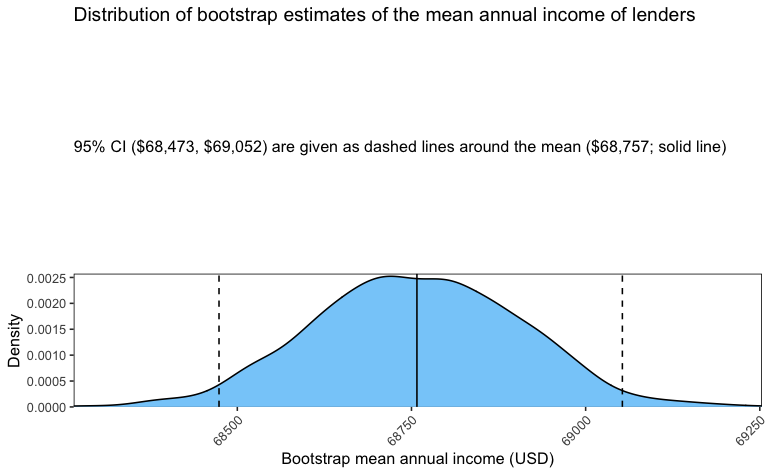

Some of the key takeaways from this section are that confidence intervals are generally calculated using bootstrapping and give some level of uncertainty around a sample estimate, not necessarily the probability of the true population parameter. Recall, confidence intervals give an estimate of the range of plausible values that a sample statistic may take given repeated sampling, if samples like the original one are drawn again.

## Normal Distribution

The standard normal distribution describes a distribution of data with a mean of 0 and a standard deviation of 1. In the broader normal distribution, we describe the distribution of observations in relation to the mean. When data follow a normal distribution, 68% of data are within one standard deviation from the mean, 95% of data are within 2 standard deviations of the mean, and approximately 98% of the data are within three standard deviations from the mean. The QQ-plot is a tool used to evaluate how closely data fit a given distribution. First, we’ll use the `rnorm()` function to sample 100 values from the standard normal distribution (mean = 0; standard deviation = 1). Second, we need to calculate the z-score, or the standardized value obtained from subtracting the mean and dividing by the standard deviation for each observation.

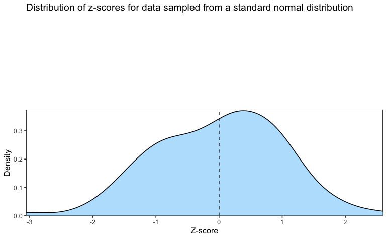

The z-scores correspond to the number of standard deviations from the mean for each observation in the original data. In the plot above, we can see that most of the z-scores are near 0. Let’s explore this further with a QQ-plot, which we can create using the `stat_qq()` function in `ggplot2`.

[figure not shown]

We can see from the plot above that most of the data follow the standard normal distribution.

## Long-Tailed Distributions

Many raw data are not normally distributed and may have long tails, or many extreme values, and some may be skewed, having many more extreme values on one end of the distribution compared to the other. To illustrate this, we’ll look at the daily stock returns of Netflix from the `sp500_px` data.

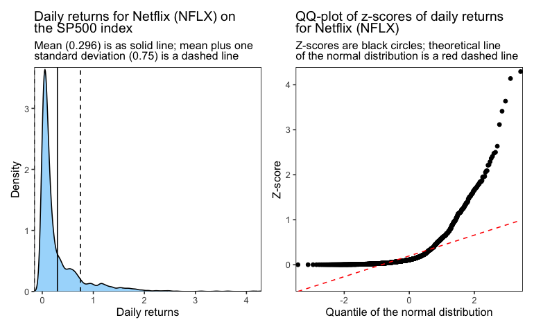

We can see from the data distribution plot on the left that the daily returns for Netflix are heavily skewed to the right, and thus do not follow a normal distribution. We can also clearly see this from the QQ-plot as well, where most of the data do not fit the expected values if they followed a normal distribution (i.e., where 68% of the data fall within one standard deviation from the mean and 95% of data fall within two standard deviations from the mean). One of the most widely used normal distributions is the t-distribution, which is often used to compare sampling distributions of test statistics after standardization. The t-distribution follows a normal distribution, generally with thicker tails, and has degrees of freedom to adjust to different sample sizes.

## Binomial Distribution

The binomial distribution, also referred to as the Bernoulli distribution, is the set of successes in a series of binary trials with two possible outcomes. In most cases, each outcome has an equal probability of success. For example, when flipping a coin, there is an equal probability that the coin will land on heads versus tails. However, in other cases, the probability of success may be different than the probability of failure (e.g., mouse clicks on a particular website advertisement). In cases where we want to know the probability of a defined number of outcomes, given a number of trials, and the probability of the outcome in each trial, we can use the `dbinom()` function. For example, using the example from the textbook, if we want to know the probability of observing exactly 0 sales out of 200 mouse clicks on a particular advertisement, and we know the probability of mouse click translating into a sale, we’d write something like this:

```r
# Calculate the probability of sales based on mouse clicks
dbinom(x = 0, size = 200, p = 0.02)
```

```
[1] 0.01758795
```

Following the binomial distribution (either a sale occurs, or it doesn’t), the probability of exactly 0 sales out of 200 clicks is relatively low. In other words, following the binomial distribution, we would expect 0 sales out of 200 clicks about 2% of the time. In other cases, we may be interested in the probability of observing a given number of outcomes or fewer out of a total number of trials and some probability of the outcome in each trial. For example, maybe we’re interested in 3 or fewer sales out of 200 clicks, again given the probability of a clicks translating to a sale is 0.02. In this case, we’d use the `pbinom()` function.

```r
# Calculate probability of 3 or fewer sales
pbinom(q = 3, size = 200, prob = 0.02)
```

```
[1] 0.431495
```

From this output, we would conclude that out of 200 clicks, we’d expect to see 3 or fewer sales about 43% of the time.

## Chi-Square Distribution

The chi-square statistic is used to evaluate the departure from the null expectation, often used with count data in defined categories. For example, the number of males versus females that received a job promotion or not, to test if there is a significant difference from what we would expect or if there is an effect of gender. The statistic is calculate by taking the difference of the observed and the expected value and dividing by the square root of the expected value, all squared. This is often referred to as a goodness-of-fit test, because the calculation of the chi-square statistic itself standardizes the statistic so it can be compared to a reference distribution. Importantly, the chi-square distribution is the distribution of the test statistic following repeated sampling from the null distribution. Thus, if the chi-square statistic closely fits the chi-square distribution (i.e., closely fits the null expectation), we would expect the value of the statistic to be low; conversely, a high value indicates the statistic does not closely following the null expectation.

## F-Distribution

The overall motivation to use the F-distribution is to compare observations to expectation under a null model, except that we’re dealing with continuous variables, not discrete counts as with the chi-square distribution. In the analysis of variance framework, we want to know if the difference in means between two groups, for example, is greater than is expected under the null model (i.e., if there was no difference in means). We essentially measure the difference in means between groups relative to the variability within groups.

## Poisson Distribution

The Poisson distribution is the frequency distribution of a number events sampled per unit of time or space. For example, the number visits to a webpage in a 5-second period could be modelled with the Poisson distribution. The Poisson distribution is controlled by the parameter lambda, which is the mean number of events that occur in a particular time frame or space, as well as the variance (these values are the same). We can model a random Poisson distribution using the `rpois()` function, which takes two arguments: the number of random numbers to draw as the first argument; and lambda, which controls the mean number of events occurring per unit of time or space, as well as the variance.

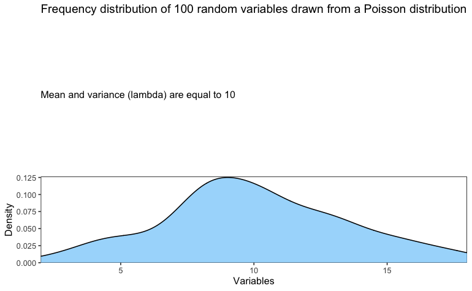

## Exponential Distribution

The exponential distribution is used to model the time between events, also using the parameter lambda that controls the mean number of events per unit time or space as well as the variance in the Poisson distribution. We can plot the frequency of random numbers drawn from the exponential distribution using the `rexp()` function, which takes two parameters: `n`, or the number of random numbers to draw; and `rate`, which controls the number of events per unit of time. One important assumption to consider is that in both the Poisson and the exponential distributions, the lambda parameter is considered to be constant.

## Weibull Distribution

This is similar to the exponential distribution to model the time between events using the parameter lambda, but importantly, in situations where the rate between events may change. The dynamic nature of the lambda parameter is controlled by the shape parameter, $\beta$, where $\beta > 1$ indicates that the probability of an event increases over time. The Weibull distribution is often used to model the time-to-failure, where in many cases, the probability of failure (e.g., mechanical failure analysis often used in engineering) increases over time.